# Why Flying During The Thanksgiving Holiday Isn’t All That Bad

## Comparing Airports

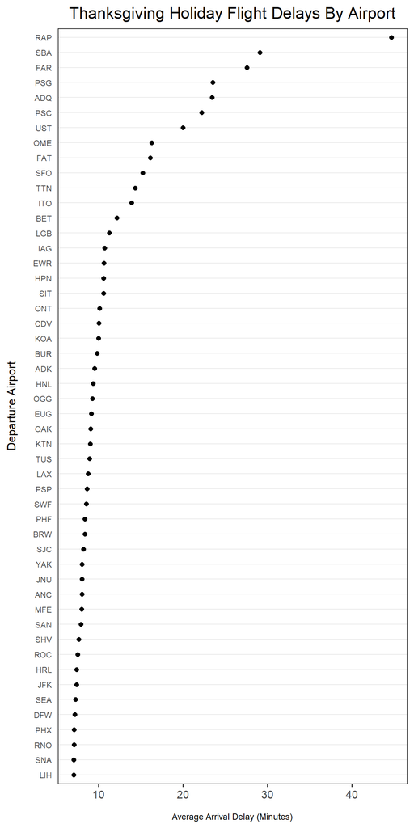

The worst-affected airports are the Rapid City, SD (RAP), Santa Barbara, CA (SBA), Fargo, ND (FAR).

Of course, many of these are small airports, so probably either (a) you’re forced to fly out of them to get where you’re going or (b) they’re of no relevance to you because you can’t change planes there.

Thus, we will focus our analysis on flights originating from the 10 biggest airports (measured specifically by the number of flights during the Thanksgiving holiday), which are much more likely to factor into a traveler’s plans.

We will also compare them to their pre-Thanksgiving performance, in order to glean more insight into which ones get worse during the holiday and which ones get better.

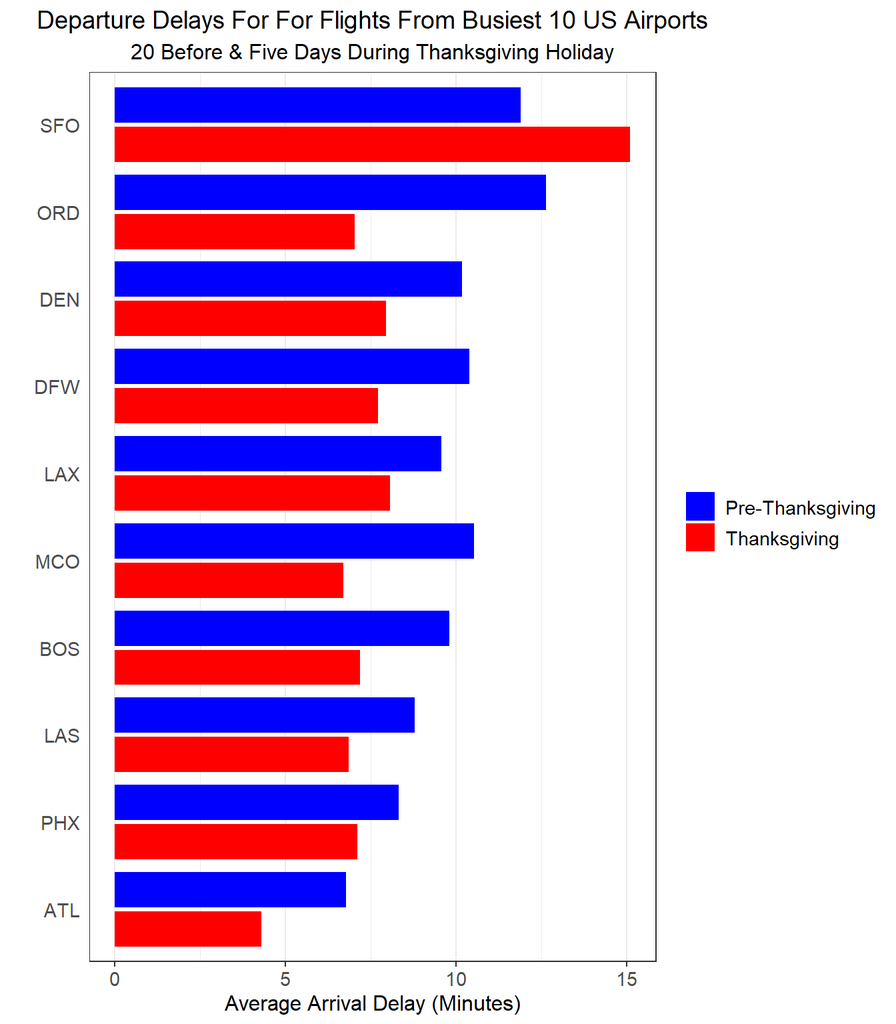

Of the top ten airports, nine get *better* and have shorter average delays during the five-day Thanksgiving holiday than the 20 days leading up to it. The only one that gets worse is San Francisco.

This is quite a revelation! It raises a lot of questions. Could there be another factor in play here that’s causing this surprising data?

We’ll examine a lot of possibilities throughout the rest of this analysis. First, we’ll compare flight cancellations per day between the “Pre-Thanksgiving” and “Thanksgiving” periods - perhaps these flights are delayed less on average because a lot more are cancelled?

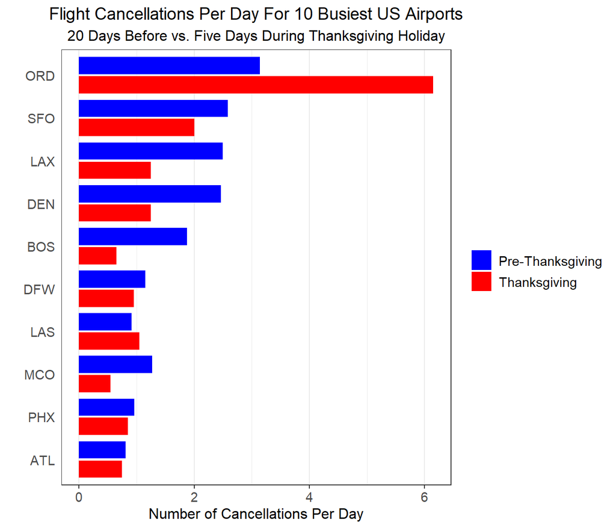

This again ties into the 2018 anamoly (don’t worry, we’ll address it shortly!).

Now we’ll start tackling the juciest question aside from airline choice - *when* do you travel?

## Comparing Days & Times Of Travel

We will now deep dive into our data to analyze how airline delays look like leading up to and post Thanksgiving. This will help us ascertain whether there is a general trend, across the years, of airline delays and cancellations on specific days.

Our data captures flight delays both at origin and destination, and as there can be multiple causes for a delay, it is subdivived into the different categories of delay such as weather delay, carrier delay, taxi delay, etc. Therefore, before we continue to analyze the flight delays and their behavior with respect to other features, we would like to fix our delay variable to one that is of most applicable.

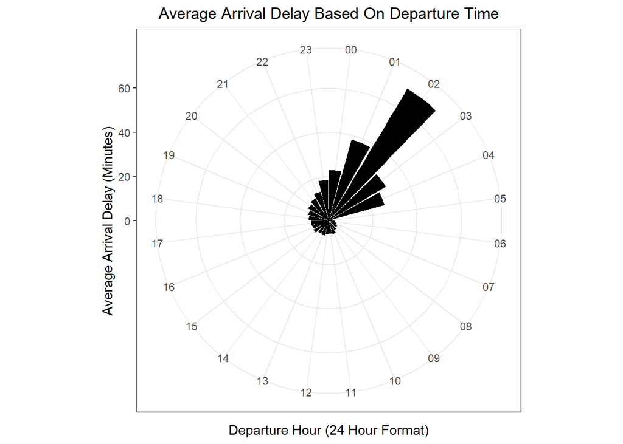

Next, we’ll examine how cancellations have fluctuated across different days across different years.

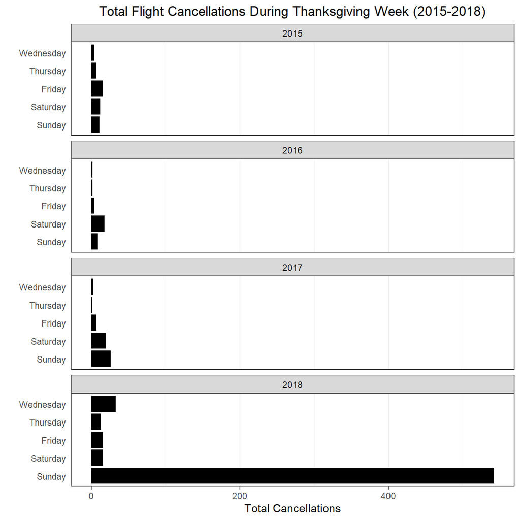

Ah, there’s our culprit!

We’ve found our outlier: Thanksgiving Sunday 2018. Clearly, something must have caused all of these cancellations, and may have skewed our data.

Let’s see what was happening on Thanksgiving Sunday, 2018.

## The Thanksgiving Sunday 2018 Flight Disaster

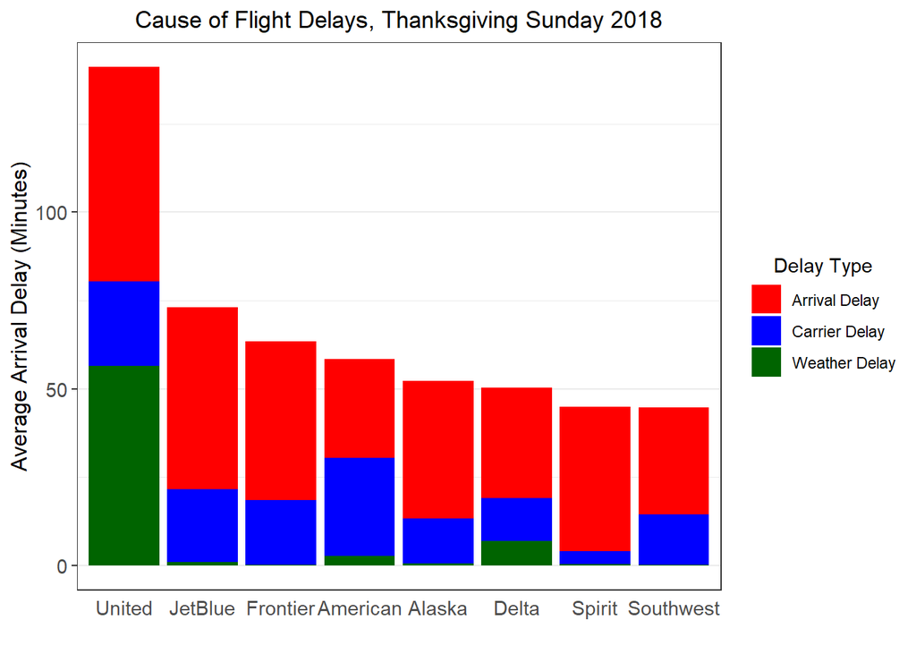

United Airlines suffered major weather delays that day. Every other delay cause stayed fairly consistent across most airlines, but United Airlines clearly suffered the most.

Continuing to deep dive into this issue, we found [a news article online talking specifically about the day and the year we were observing.](https://www.usatoday.com/story/travel/flights/todayinthesky/2018/11/25/snow-flights-canceled-storm-snarls-post-thanksgiving-sunday/2107525002/)

A snippet from this aricle:

*Most of those came in the Midwest, where a winter storm was bringing snow, ice and rain to a swath of the Great Plains and Midwest. Blizzard conditions were possible Sunday across parts of Iowa, Illinois, Missouri and Wisconsin.*

*O’Hare is a major connecting hub for both United and American, each of which had canceled hundreds of mainline and regional flights. By FlightAware’s count. the cancellations accounted for more than 25 percent of Sunday’s entire schedule at O’Hare. For Monday, more than 180 flights – about 5 percent of the day’s schedule – had already been grounded by Sunday evening.*

Looking at aiports may give us more insight:

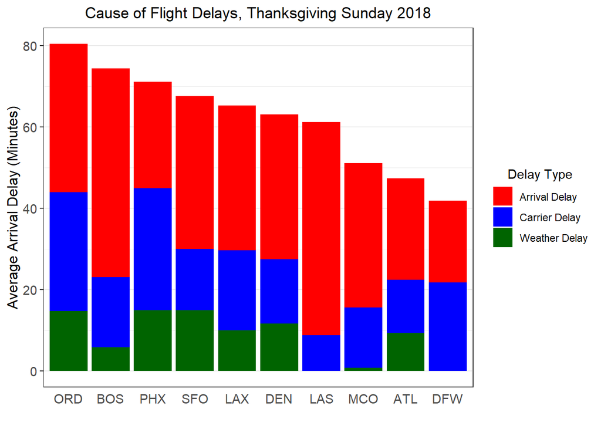

Chicago O’Hare, San Francisco, and Denver are all United hubs and had significant weather delays, so it makes sense that United would have suffered the most from the weather.

This backs our hypothesis that the delay on this particular day was due to weather reasons, and was not because of Thanksgiving rush.

This is an important caveat to our data. We opted to keep it in as weather is just one of many challenges airlines face, but it certainly skews the data against United a bit.

Perhaps we should examine how badly 2018 penalized United (and maybe other airlines).

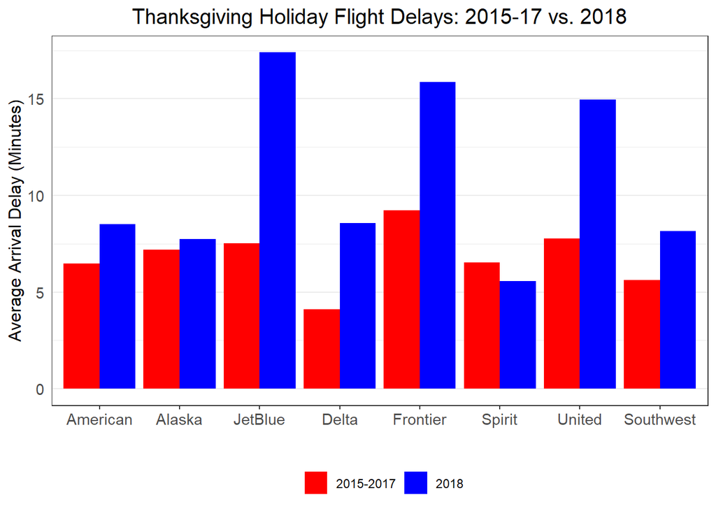

United would still be among the worst airines for Thanksgiving OTP even without 2018, but 2018 (particularly that Sunday) made United look worse than it normally is. A similar statement could be made about Frontier and JetBlue.

Next, we’ll move to comparing the Thanksgiving and ‘Pre-Thanksgiving’ holiday periods.

## The Major Revelation: Maybe Thanksgiving Isn’t So Bad

We will now answer a vital question: how has airline OTP (on-time performance) during the Thanksgiving holiday compared to airline OTP outside of the Thanksgiving holiday since the mergers of the major US airlines?

We will research this question by comparing the 20 days before the Thanksgiving travel rush to the 5 days of the Thanksgiving travel period, in order ensure that we stay in a season with similar weather and travel patterns. We note, however, that likely captured *some* early Thanksgiving travel (which can be equally or perhaps even moreso plagued by delays).

We also share a caveat (which applies to all this research) that the four years since the recent major US airline mergers completed is a small sample size, and major weather events and airline disruptions could cause some skewness in this data.

That being said, let’s compare Thanksgiving and pre-Thanksgiving.

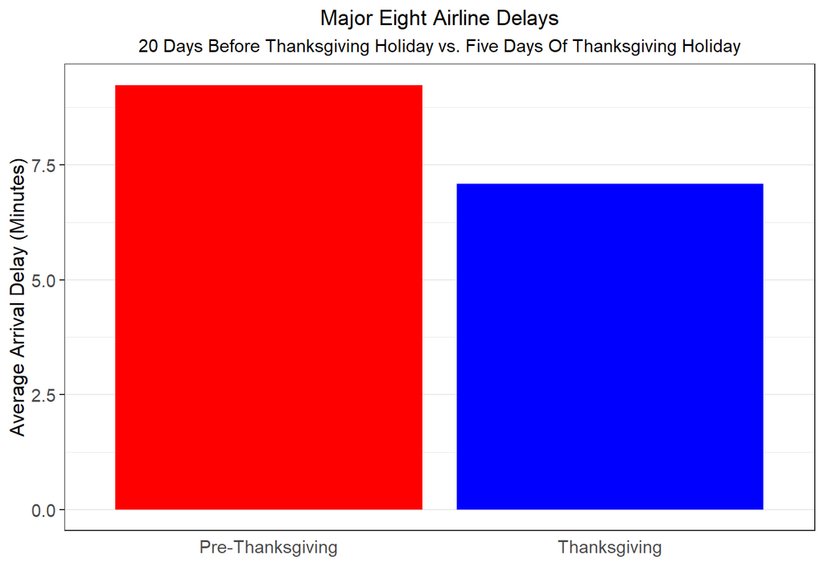

A stunner: over the past four years, airlines have actually gotten better at on-time performance during Thanksgiving.

There’s an important caveat worth mentioning here: the data we are using considers any early flight to be simply “on-time” (and does not give it a negative delay value), as we believe that it makes the most sense to call a spade a spade and consider any flight that isn’t late to be on time.

However, flights are typically early when all goes right, so it’s possible that Thanksgiving causes a lot of shorter “delays” that result in flights being on-time instead of early, meaning Thanksgiving flights aren’t really quicker.

Still though, with that caveat, our result stands: and at the very least, it seems evident that delays don’t get worse during Thanksgiving (at least for flights that aren’t cancelled or diverted, which we’ll address later).

Now let’s examine how this trend plays out for different airlines.

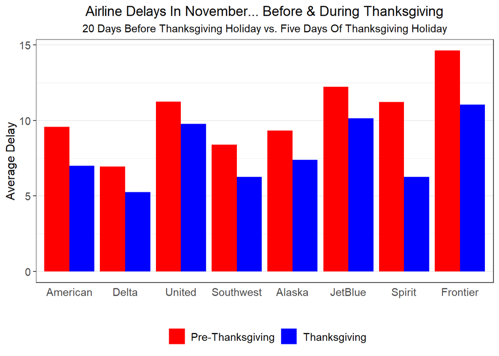

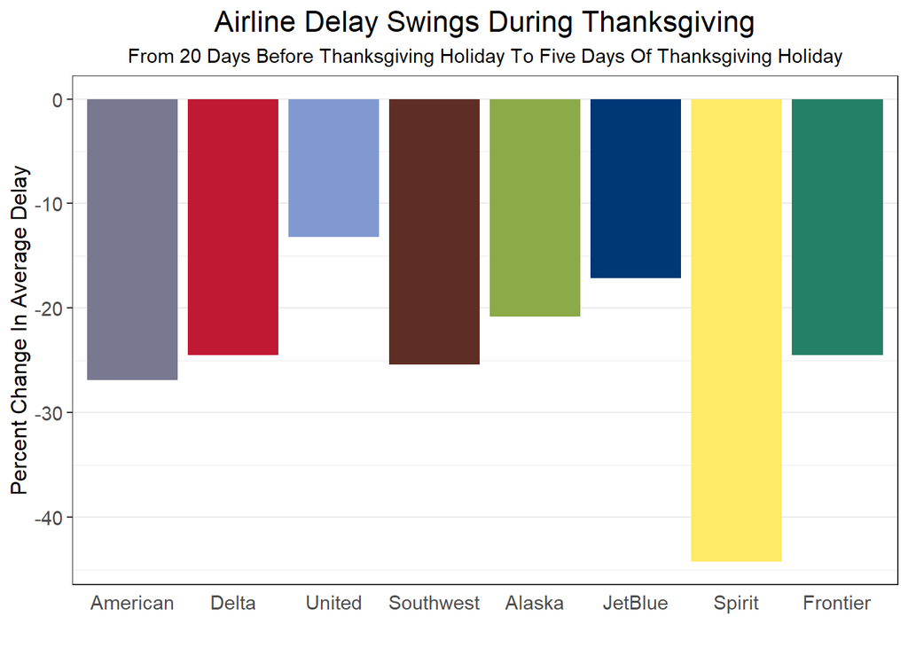

All eight airlines see their on-time performance improve during Thanksgiving.

Outside of that, the most evident (and strangest) trend here is that Spirit Airlines and Frontier Airlines - two ultra low-cost carriers with poor service reputations - have had a significantly shorter average flight delay during the Thanksgiving holiday than they did prior to the Thanksgiving holiday, particularly Spirit Airlines.

This suggests that there is no need to avoid Spirit and Frontier during the Thanksgiving holiday. In fact, one could argue if there’s any time to fly these airlines, it’s Thanksgiving: their OTP has lagged much less during this peak travel period. United (the third-worst airline for OTP) also sees an improvement in performance during Thanksgiving.

Perhaps Thanksgiving has a normalizing effect on these airlines. Frontier technically still has the worst Thanksgiving travel delays of any of these airlines, but they close the gap by a remarkable margin.

So flight delays are shorter during Thanksgiving. Surprise!

Are there more long delays, though - say, those over 30 minutes? Let’s consider that now.

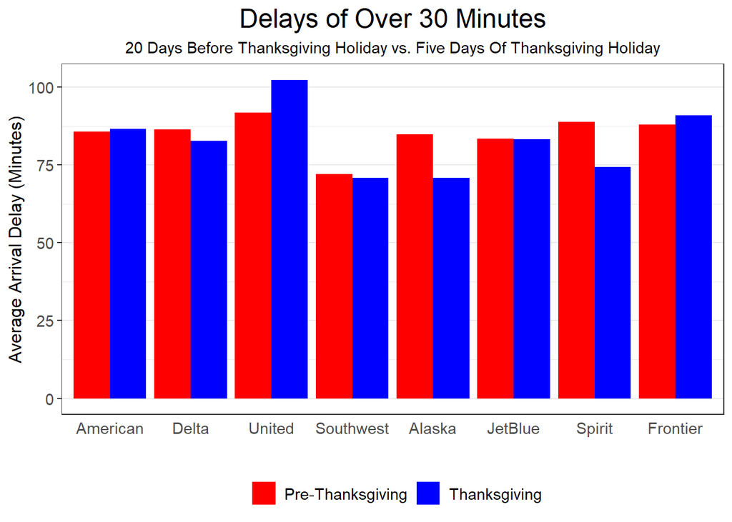

It seems that long delays are fairly evenly distributed across all airlines and dates, so not much to add there.

What about *really* long delays though? Which airlines have the most of those, and during what period do these happen the most?

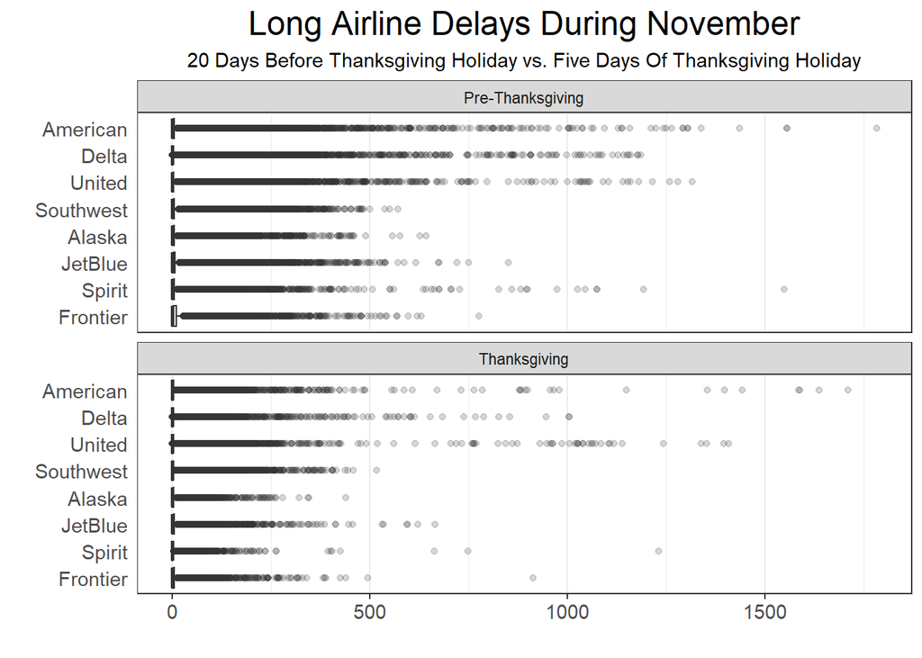

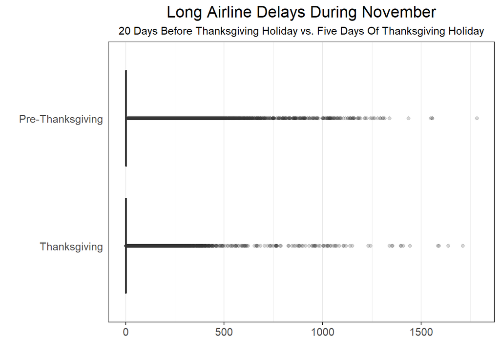

It’s worth noting that more flights creates more dots here (there are about four times as many flights during the “Pre-Thanksgiving” period and the larger airlines have more flights overall), so we’re looking for where the dots cluster, rather than how many dots there are overall in a given area.

Delta appears to improve in this area during the holiday. American and United remain the worst offenders. Interestingly, Spirit again sees quite an improvement during the holiday period, with far fewer serious delays. There isn’t too much change overall in the number of serious delays between the two periods.

But now… what about the flights that aren’t delayed, but just get flat-out cancelled, and thus don’t even don’t have a delay value to factor in? Maybe a lot of flights get cancelled during Thanksgiving, and that removes bad delays from the sample space?

Let’s take a look.

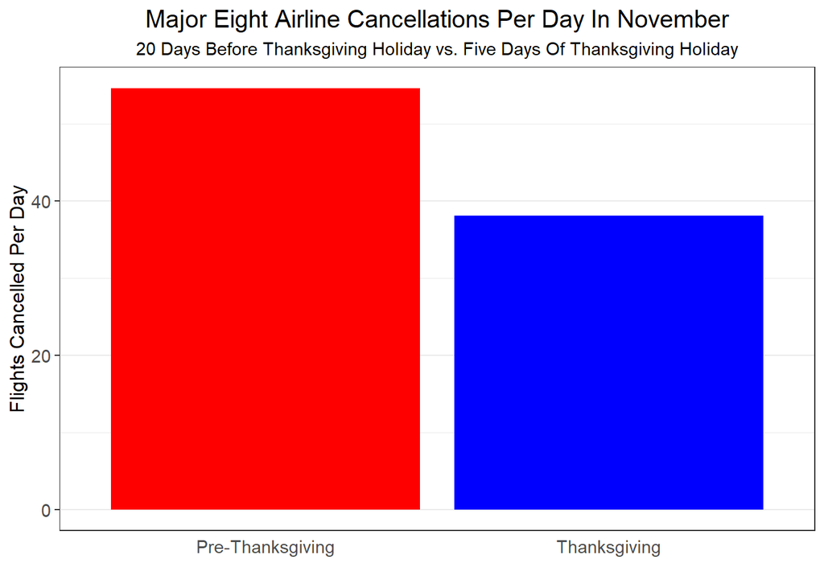

We expected a rub here, but alas, cancellations drop as well during the Thanksgiving holiday. This further confirms our surprising result: at least over the last four years, traveling during Thanksgiving has been less delay- and cancellation-ridden than traveling before Thanksgiving.

Next we take a look at which airlines stepped up their getting-off-the-ground game the most.

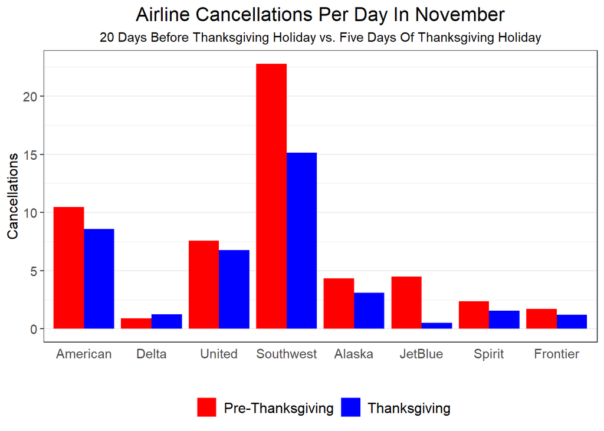

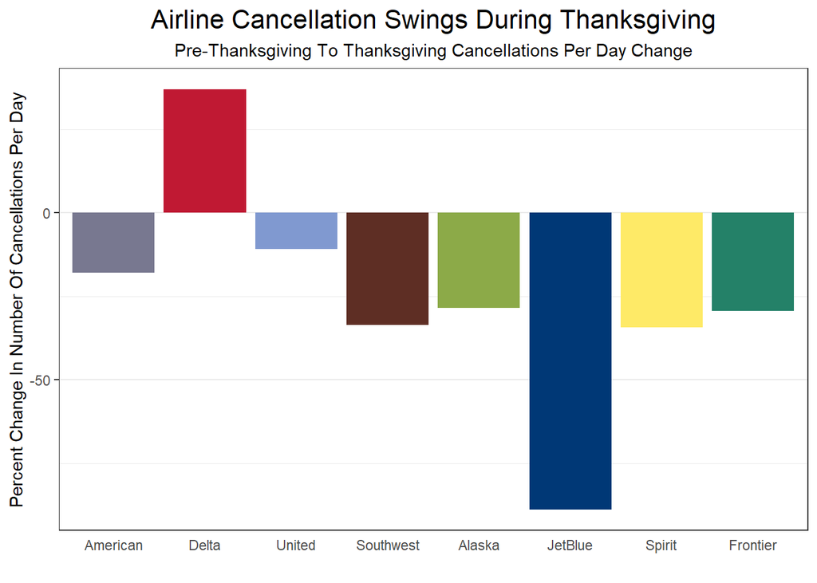

This suggests that cancellations are high-variation, “luck of the draw” (or more aptly put, “lack of luck of the draw”) events, and measuring their swings is probably a fool’s errand.

That being said, JetBlue has done an exceptionally good job of getting their flights in the air over the last four Thanksgiving holidays.

It’s also worth noting that Southwest seems to have had extreme cancellation problems during the last four Novembers, but performed better during the holiday than before the holiday period.

Most airlines appeared to get a bit better at getting their flights in the air, except Delta, which was the only airline out of the eight to have more cancellations during the Thanksgiving holiday.

So let’s see- if we examine the five days of the Thanksgiving travel rush and the 20 days before, do we see a peak in delays at any particular point? Could it be that the worst delays happen 3-5 days before Thanksgiving (i.e. the weekend before plus Monday and Tuesday), rather than during the traditional travel rush?

Let’s see what the graphs say.

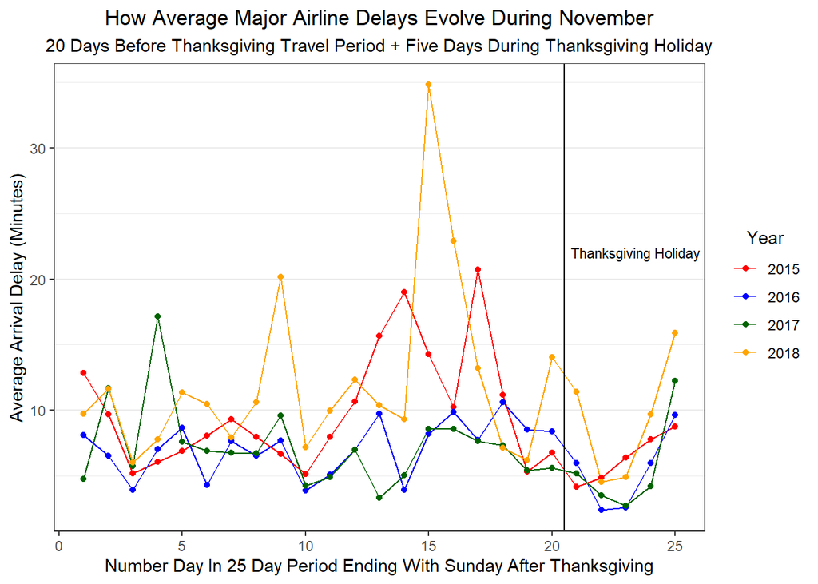

This is odd - we’re seeing a number of peaks before the Thanksgiving holiday even begins. Perhaps we should combine these years and see what trend develops.

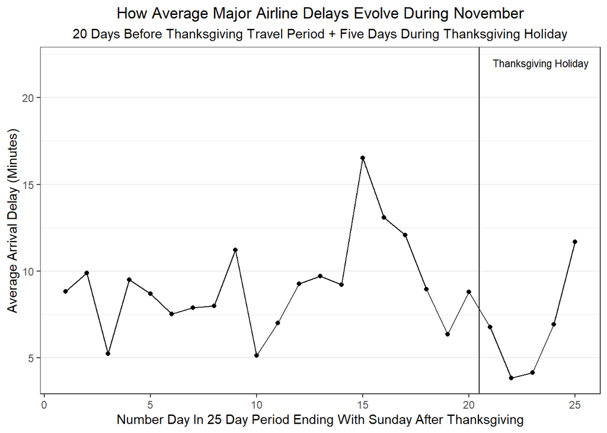

Very strange - while there’s a peak at the end of the Thanksgiving holiday (the final day is that dreaded Thanksgiving Sunday), there’s another peak about a week before Thanksgiving that’s worse than that final Sunday, and much worse than the traditionally-dreaded Thanksgiving Wednesday. Perhaps people are leaving earlier than we thought.